# DESeq.rmd

## R Markdown

En premier lieu, on a besoin d’importer le tximport:

```r
library("tximport")
```

Puis, on importe les fichiers que l’on va utiliser comme le résultat des salmon_quant fait précédemment, ainsi que gene_trans_map que l’on a obtenu avec Trinity:

```r
# création de la variable pour la boucle for
varion <- c(1,2,3,4,5,6)

#création de la liste de fichier de salmon_quant
fichier <- c()

#la boucle for pour insérer les fichiers dans la liste "fichier"
for (i in varion) {
  fichier[i] <- paste0("/ifb/data/mydatalocal/mydata/salmon_quant/quant_",i,"/quant.sf")
}

#rajout d'un nom à chaque fichier
names(fichier) <- c("Lib1_31_20_S1","Lib2_31_20_S2","Lib3_31_20_S3","Lib4_31_20_S4","Lib5_31_20_S5","Lib6_31_20_S6")

#recuperation de la map dans trinity, modifier les nom de titres et remi les colonnes dans le bon sens pour que la suite se fasse sans problème.
trini <- read.table("/ifb/data/mydatalocal/mydata/trinity/Trinity_RF.fasta.gene_trans_map")
names(trini) <- c("GENEID","TXNAME")
trini1 <- trini[,c(2,1)]

#réalisation de tximport dans txi
txi <- tximport(fichier, type = "salmon", tx2gene = trini1)
```

```
## reading in files with read_tsv
```

```
## 1 2 3 4 5 6
## summarizing abundance
## summarizing counts
## summarizing length
```

Avant de lancer de DEseq, on a besoin d’importer la bibliothèque DEseq2:

```r
library("DESeq2")
```

Puis, après avoir réaliser le data.frame permettant de pouvoir faire le l’analyse (en définissant les contrôles (CTL) et les échantillons avec induction d’IFN (IFN)), j’ai utiliser DESeqDataSetFromTximport affin de compiler les informations dépendamment des conditions :

```r
#creation du data.frame de sample avec nos 2 conditions
samp.name <- c("Lib1_31_20_S1","Lib2_31_20_S2","Lib3_31_20_S3","Lib4_31_20_S4","Lib5_31_20_S5","Lib6_31_20_S6")
samp.type <- factor(rep(c("CTL", "IFN"), each = 3))
samples <- data.frame(run=samp.name,condition=samp.type)

#realization de DEseq2
ddsTxi <- DESeqDataSetFromTximport(txi,
                                   colData = samples,
                                   design = ~ condition)
```

```
## using counts and average transcript lengths from tximport
```

Les résultats obtenus sont pas la suite compilés avec DESeq puis on récupère les résultats sout forme de tableau grâce à results dans la variable res :

```r
dds <- DESeq(ddsTxi)
```

```
## using 'avgTxLength' from assays(dds), correcting for library size
```

```r
res <- results(dds)
```

Une fois le résultat obtenu, on regarde à quel moment on obtient une différence significative entre les 2 conditions pour des valeur entre eux (**il s’agit de là de la p-value ajusté = padj**) :

```r
# pour 0.1 :
table(res$padj < 0.1)
```

```
##
##  FALSE   TRUE
## 294034   1745
```

```r
# pour 0.05
table(res$padj < 0.05)
```

```
##
##  FALSE   TRUE
## 294322   1457
```

```r
# pour 0.01 :
table(res$padj < 0.001)
```

```
##
##  FALSE   TRUE
## 295004    775
```

En première lieu, on peut y constater que lorsque l’on regarde dans la variable res la p-value ajustée, il n’y a que **1 745** transcris en-dessous de 0,1 contre **294 034** au-dessus. Ce nombre est très faible bien que la limite soit assez haute (10 % de faux positifs). Plusieurs facteurs peuvent expliquer cela:

- Premièrement, il y est possible qu’il y est eu une erreur de manipulation.
- deuxièmement, il se peut que l’on ne peut pas bien mesurer le différence vu que ce n’est pas *in vivo* mais *in vitro*, ou bien que la concentration d’IFN infecté est différente que celle *in vivo*.
- Troisièmement, c’est bien le résultat que l’on obtient et dans ce cas il n’y a que très peu de gènes réguler par l’induction d’IFN.

Réalisation des figures grâce au résultat obtenu dans la variable res (visible dans le README.md):

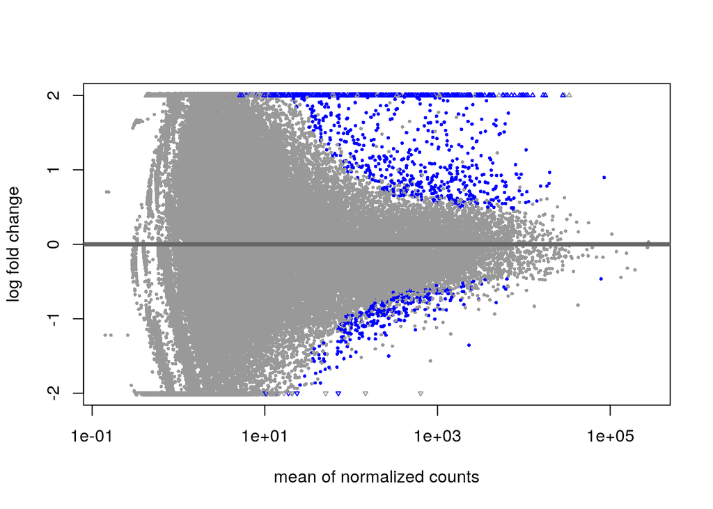

```r
plotMA(res, ylim=c(-2,2))
```

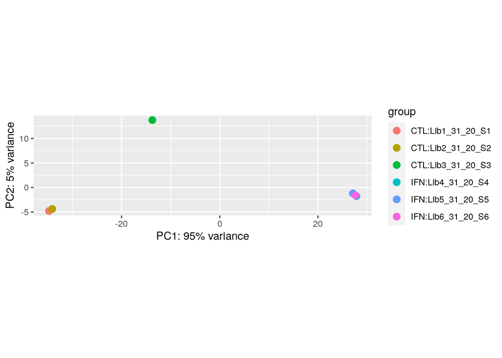

```r
vsd <- vst(dds, blind=FALSE)
plotPCA(vsd, intgroup=c("condition","run"))
```

Par la suite, si on regarde la première figure ci-dessus, on peut y constater que les points bleus (avec un différence significative entre le contrôle et l’induction d’IFN) sont majoritairement présents dans la partie du haut, avec énormément qui sortent du cadre (symbolisé par un triangle). Cela signifie que donc la majorité des gènes significativement régulés le sont sur-exprimé par l’induction d’IFN que sous-exprimer.

Concernant la seconde figure, on peut et constater que le Lib3 (qui est l’un des trois contrôles) se trouve avec une différence très élevé par rapport aux deux autres contrôles. Tendit que les trois tests avec l’induction d’IFN sont pour eux tous les trois similaires. Ce résultat est inattendu et pourrait être l’une des explications du faible nombre de gènes réguler par l’induction d’IFN. On a pu constater que cette différence peut être dû par le faite que le troisième contrôle a eu sa banque qui a été à refaire et donc qui n’a pas été fait en même temps que les autres échantillons.

Refaire les analyses en enlevant le troisième contrôle pourrait être faite, mais il faut bien prendre en compte que cela risque de fortement diminué la robustesse des analyses car on aura plus que deux contrôles, n’étant pas suffisant pour réaliser correctement un teste statistiques. Nous avons finalement réalisé cela afin de voir si cela est suffisant pour expliquer le faible nombre de transcrit régulier Différentiellement.

## test sans Lib3 car problème dû à une banque qui n’a pas marché et donc fait un autre jour. Juste pour voir.

Mise à part le fait que Lib3 ne soit pas pris en compte ici, c’est exactement les mêmes chose que précédemment (sauf une modification dans la boucle ci-dessous oû elle a été modifiée pour ne pas prendre en compte Lib3) :

```r
library("tximport")
```

```r
# création de la variable pour la boucle for
varionx <- c(1,2,3,4,5)

#création de la liste de fichier de salmon_quant
fichierx <- c()

#la boucle for pour insérer les fichiers dans la liste "fichier"
for (i in varionx) {
  if (i > 2) {
    z = i+1
    fichierx[i] <- paste0("/ifb/data/mydatalocal/mydata/salmon_quant/quant_",z,"/quant.sf")
  } else {
    fichierx[i] <- paste0("/ifb/data/mydatalocal/mydata/salmon_quant/quant_",i,"/quant.sf")
  }
}

#rajout d'un nom à chaque fichier
names(fichierx) <- c("Lib1_31_20_S1","Lib2_31_20_S2","Lib4_31_20_S4","Lib5_31_20_S5","Lib6_31_20_S6")

#recuperation de la map dans trinity, modifier le nom et remi les colonnes dans le bon sens pour la suite
trinix <- read.table("/ifb/data/mydatalocal/mydata/trinity/Trinity_RF.fasta.gene_trans_map")
names(trinix) <- c("GENEID","TXNAME")
trinix1 <- trinix[,c(2,1)]

#réalisation de tximport dans txi
txix <- tximport(fichierx, type = "salmon", tx2gene = trinix1)
```

```
## reading in files with read_tsv
```

```
## 1 2 3 4 5
## summarizing abundance
## summarizing counts
## summarizing length
```

```r
library("DESeq2")
```

```r
#creation du data.frame de sample avec nos 2 conditions
samp.namex <- c("Lib1_31_20_S1","Lib2_31_20_S2","Lib4_31_20_S4","Lib5_31_20_S5","Lib6_31_20_S6")
samp.typex <- factor(c("CTL","CTL","IFN","IFN","IFN"))
samplesx <- data.frame(run=samp.namex,condition=samp.typex)

#realization de DEseq2
ddsTxix <- DESeqDataSetFromTximport(txix,
                                   colData = samplesx,
                                   design = ~ condition)
```

```
## using counts and average transcript lengths from tximport
```

```r
ddsx <- DESeq(ddsTxix)
```

```
## using 'avgTxLength' from assays(dds), correcting for library size
```

```r
resx <- results(ddsx)
```

```r
# pour 0.1 :
table(resx$padj < 0.1)
```

```
##
##  FALSE   TRUE
## 287553   1896
```

```r
# pour 0.05 :
table(resx$padj < 0.05)
```

```
##
##  FALSE   TRUE
## 287779   1670
```

```r
# pour 0.01 :
table(resx$padj < 0.001)
```

```
##
##  FALSE   TRUE
## 288464    985
```

Nous pouvons ici y constaté que enlever le troisième contrôle n’a affecté que très faiblement le nombre de transcrit qui sont régulé significativement par l’induction d’IFN. Celui-ci reste très faible passant de **1 745** à **1 896**.

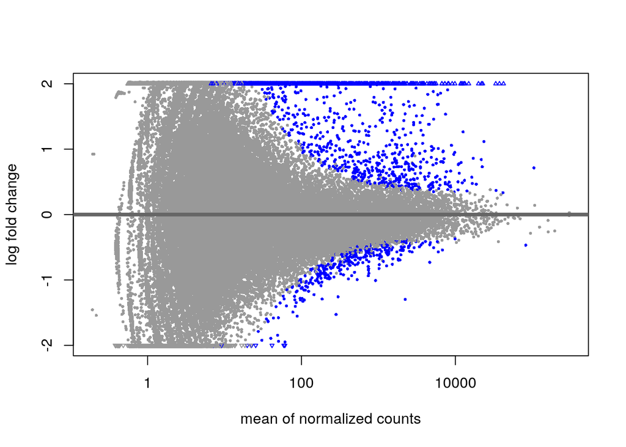

```r
plotMA(resx, ylim=c(-2,2))
```

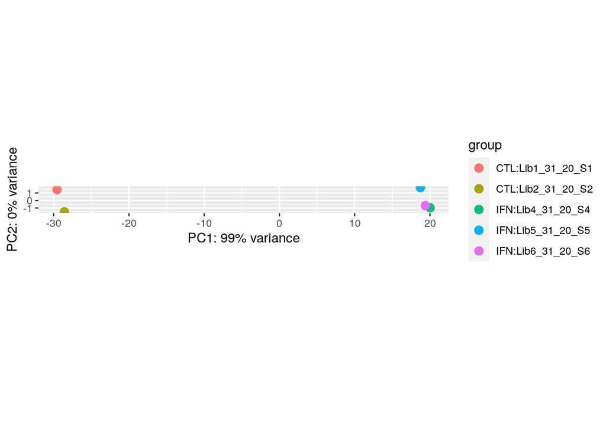

```r
vsdx <- vst(ddsx, blind=FALSE)
plotPCA(vsdx, intgroup=c("condition","run"))
```

Ici, nous n’y constatons pas vraiment de grosse différence non plus.

# La comparaison

## Réalisation d’une combination de nos résultats de res avec les gènes d’Homo sapiens

Pour commencer, nous devons installer BiocManager et biomaRt:

```r
#if (!requireNamespace("BiocManager", quietly = TRUE))
#    install.packages("BiocManager")
#BiocManager::install("biomaRt")
library(biomaRt)
```

Puis, nous avons importé les bibliothèques suivantes pour la suite :

```r
library(dplyr)
library(tidyr)
```

```r
library(ggplot2)
library(data.table)
```

Ici, nous avons lancé le mélange entre res et Homo sapiens :

```r
ensembl <- useEnsembl(biomart = "genes", dataset = "hsapiens_gene_ensembl")
tx2geneHomo = biomaRt::getBM(attributes=c('ensembl_transcript_id',
                                      'ensembl_gene_id', 'external_gene_name'),mart=ensembl)
blastHomo <- read.table("/ifb/data/mydatalocal/mydata/blast/blastn/blastn.blast")
blastHomo <- data.table(blastHomo)
blastHomo <- blastHomo[, c("trid", "version") := tstrsplit(V2, ".", fixed=TRUE)][]
blastHomo <- blastHomo[, c("gene", "alttr") := tstrsplit(V1, "_i", fixed=TRUE)][]
blastHomo1 <- blastHomo%>% group_by(gene)%>% slice_max(order_by = V12, n = 1, with_ties = TRUE)
blastHomoName <- merge(tx2geneHomo,blastHomo1,by.x="ensembl_transcript_id",by.y="trid")
blastHomoNameUniq <- unique(blastHomoName[,c("ensembl_gene_id","external_gene_name","gene")])

# associate our DE results with gene names from human
resUsName=merge(as.data.frame(res),blastHomoNameUniq,by.x=0,by.y="gene")
```

Afin de pouvoir analyser uniquement pour les gènes sur- ou sous-réguler ou les 2, j’ai réaliser les codes suivants pour spécifiquement 5 % d’erreurs avec la p-value ajusté :

```r
#pour sur-stranscrit
UpReg <- filter(resUsName, padj<0.05 & resUsName$log2FoldChange>0)
head(UpReg)
```

```
##                Row.names   baseMean log2FoldChange     lfcSE     stat
## 1  TRINITY_DN10013_c0_g1   45.58055      1.8827404 0.4261442 4.418082
## 2   TRINITY_DN1004_c0_g1 1644.23403      0.5699289 0.1349904 4.221997
## 3 TRINITY_DN100523_c0_g1 8931.53209      4.7650871 1.0518145 4.530350
## 4   TRINITY_DN1010_c1_g1  636.51390      0.9795629 0.1686732 5.807459
## 5  TRINITY_DN10127_c0_g1   72.69400      1.8499651 0.3378255 5.476097
## 6  TRINITY_DN10135_c0_g1  767.75276      0.8720686 0.1817557 4.798027
##         pvalue         padj ensembl_gene_id external_gene_name
## 1 9.958045e-06 3.302835e-03 ENSG00000078018               MAP2
## 2 2.421477e-05 7.091308e-03 ENSG00000019549              SNAI2
## 3 5.888618e-06 2.066108e-03 ENSG00000205413              SAMD9
## 4 6.342817e-09 4.150602e-06 ENSG00000214827              MTCP1
## 5 4.348106e-08 2.521722e-05 ENSG00000158473               CD1D
## 6 1.602363e-06 6.439476e-04 ENSG00000151304             SRFBP1
```

```r
#pour sous-transcrit
DownReg <- filter(resUsName, padj<0.05 & resUsName$log2FoldChange<0)
head(DownReg)
```

```
##               Row.names  baseMean log2FoldChange     lfcSE      stat
## 1 TRINITY_DN10742_c0_g1  191.0273     -1.2705882 0.2073428 -6.127958
## 2 TRINITY_DN10967_c0_g2  332.3173     -1.0361643 0.2302463 -4.500243
## 3  TRINITY_DN1132_c0_g1  459.0541     -0.7977587 0.1820953 -4.380995
## 4 TRINITY_DN11391_c0_g1  398.8642     -0.7630451 0.2001139 -3.813054
## 5  TRINITY_DN1151_c0_g2  791.5909     -0.7155783 0.1929415 -3.708783
## 6 TRINITY_DN11541_c0_g1 2415.3854     -0.5053086 0.1345602 -3.755260
##         pvalue         padj ensembl_gene_id external_gene_name
## 1 8.901391e-10 6.516942e-07 ENSG00000171130           ATP6V0E2
## 2 6.787568e-06 2.350843e-03 ENSG00000115526             CHST10
## 3 1.181385e-05 3.814726e-03 ENSG00000146858           ZC3HAV1L
## 4 1.372602e-04 3.115785e-02 ENSG00000285241               PCK2
## 5 2.082580e-04 4.368677e-02 ENSG00000166974             MAPRE2
## 6 1.731616e-04 3.779894e-02 ENSG00000102931             ARL2BP
```

```r
#pour tous les significativement transcrit différemment
AllReg <- filter(resUsName, padj<0.05)
head(AllReg)
```

```
##                Row.names   baseMean log2FoldChange     lfcSE     stat
## 1  TRINITY_DN10013_c0_g1   45.58055      1.8827404 0.4261442 4.418082
## 2   TRINITY_DN1004_c0_g1 1644.23403      0.5699289 0.1349904 4.221997
## 3 TRINITY_DN100523_c0_g1 8931.53209      4.7650871 1.0518145 4.530350
## 4   TRINITY_DN1010_c1_g1  636.51390      0.9795629 0.1686732 5.807459
## 5  TRINITY_DN10127_c0_g1   72.69400      1.8499651 0.3378255 5.476097
## 6  TRINITY_DN10135_c0_g1  767.75276      0.8720686 0.1817557 4.798027
##         pvalue         padj ensembl_gene_id external_gene_name
## 1 9.958045e-06 3.302835e-03 ENSG00000078018               MAP2
## 2 2.421477e-05 7.091308e-03 ENSG00000019549              SNAI2
## 3 5.888618e-06 2.066108e-03 ENSG00000205413              SAMD9
## 4 6.342817e-09 4.150602e-06 ENSG00000214827              MTCP1
## 5 4.348106e-08 2.521722e-05 ENSG00000158473               CD1D
## 6 1.602363e-06 6.439476e-04 ENSG00000151304             SRFBP1
```

Téléchargement des données afin de regarder quelle sont les processus et fonction moléculaire ainsi que les compartiments cellulaires impacter

```r
write.csv(as.data.frame(unique(resUsName$external_gene_name)),
          file="/ifb/data/mydatalocal/download/name_all.csv",quote=FALSE,row.names = FALSE)

write.csv(as.data.frame(unique(UpReg$external_gene_name)),
          file="/ifb/data/mydatalocal/download/name_up.csv",quote=FALSE,row.names = FALSE)

write.csv(as.data.frame(unique(DownReg$external_gene_name)),
          file="/ifb/data/mydatalocal/download/name_down.csv",quote=FALSE,row.names = FALSE)

write.csv(as.data.frame(unique(AllReg$external_gene_name)),
          file="/ifb/data/mydatalocal/download/name_allreg.csv",quote=FALSE,row.names = FALSE)
```

# pour sans le CTL3 :

Puis, nous avons importé les bibliothèques suivantes pour la suite :

```r
library(dplyr)
library(tidyr)
library(data.table)
library(ggplot2)
```

Ici, nous avons lancé le mélange entre res et Homo sapiens :

```r
ensembl <- useEnsembl(biomart = "genes", dataset = "hsapiens_gene_ensembl")
tx2geneHomo = biomaRt::getBM(attributes=c('ensembl_transcript_id',
                                      'ensembl_gene_id', 'external_gene_name'),mart=ensembl)
blastHomo <- read.table("/ifb/data/mydatalocal/mydata/blast/blastn/blastn.blast")
blastHomo <- data.table(blastHomo)
blastHomo <- blastHomo[, c("trid", "version") := tstrsplit(V2, ".", fixed=TRUE)][]
blastHomo <- blastHomo[, c("gene", "alttr") := tstrsplit(V1, "_i", fixed=TRUE)][]
blastHomo1 <- blastHomo%>% group_by(gene)%>% slice_max(order_by = V12, n = 1, with_ties = TRUE)
blastHomoName <- merge(tx2geneHomo,blastHomo1,by.x="ensembl_transcript_id",by.y="trid")
blastHomoNameUniq <- unique(blastHomoName[,c("ensembl_gene_id","external_gene_name","gene")])
# associate our DE results with gene names from human
resUsNamex=merge(as.data.frame(resx),blastHomoNameUniq,by.x=0,by.y="gene")
```

Afin de pouvoir analyser uniquement pour les gènes sur- ou sous-réguler ou les 2, j’ai réaliser les codes suivants pour spécifiquement 5 % d’erreurs avec la p-value ajusté :

```r
#pour sur-stranscrit
UpRegx <- filter(resUsNamex, padj<0.05 & resUsName$log2FoldChange>0)
head(UpRegx)
```

```
##                Row.names    baseMean log2FoldChange      lfcSE      stat
## 1    TRINITY_DN100_c0_g1  4780.51915      0.3978716 0.09949082  3.999078
## 2  TRINITY_DN10013_c0_g1    56.11158      1.6000979 0.42824957  3.736368
## 3   TRINITY_DN1004_c0_g1  1808.16810      0.5356289 0.11323050  4.730430
## 4 TRINITY_DN100523_c0_g1 11740.97470      6.6107338 0.12725578 51.948396
## 5   TRINITY_DN1010_c1_g1   733.79776      1.0772280 0.13553663  7.947874
## 6  TRINITY_DN10127_c0_g1    81.58107      2.0843940 0.34346049  6.068803
##         pvalue         padj ensembl_gene_id external_gene_name
## 1 6.358963e-05 1.354375e-02 ENSG00000275272             YTHDC1
## 2 1.866975e-04 3.428896e-02 ENSG00000078018               MAP2
## 3 2.240452e-06 6.950660e-04 ENSG00000019549              SNAI2
## 4 0.000000e+00 0.000000e+00 ENSG00000205413              SAMD9
## 5 1.897396e-15 1.430206e-12 ENSG00000214827              MTCP1
## 6 1.288671e-09 6.196087e-07 ENSG00000158473               CD1D
```

```r
#pour sous-transcrit
DownRegx <- filter(resUsNamex, padj<0.05 & resUsName$log2FoldChange<0)
head(DownRegx)
```

```
##               Row.names  baseMean log2FoldChange     lfcSE      stat
## 1 TRINITY_DN10544_c0_g1  403.0584     -0.7518378 0.1667554 -4.508627
## 2 TRINITY_DN10742_c0_g1  185.3812     -1.2916726 0.2085844 -6.192566
## 3  TRINITY_DN1085_c0_g1  232.9534     -0.7815083 0.1936477 -4.035722
## 4 TRINITY_DN10967_c0_g2  304.0222     -0.8150781 0.1967372 -4.142979
## 5 TRINITY_DN11205_c2_g1 1483.1202     -0.5409679 0.1240068 -4.362405
## 6  TRINITY_DN1132_c0_g1  490.1075     -0.8834361 0.1661530 -5.317003
##         pvalue         padj ensembl_gene_id external_gene_name
## 1 6.524836e-06 1.809011e-03 ENSG00000116062               MSH6
## 2 5.919260e-10 2.974521e-07 ENSG00000171130           ATP6V0E2
## 3 5.443457e-05 1.190932e-02 ENSG00000138686               BBS7
## 4 3.428236e-05 7.875393e-03 ENSG00000115526             CHST10
## 5 1.286405e-05 3.292206e-03 ENSG00000151835               SACS
## 6 1.054904e-07 4.154299e-05 ENSG00000146858           ZC3HAV1L
```

```r
#pour tous les significativement transcrit différemment
AllRegx <- filter(resUsNamex, padj<0.05)
head(AllRegx)
```

```
##                Row.names    baseMean log2FoldChange      lfcSE      stat
## 1    TRINITY_DN100_c0_g1  4780.51915      0.3978716 0.09949082  3.999078
## 2  TRINITY_DN10013_c0_g1    56.11158      1.6000979 0.42824957  3.736368
## 3   TRINITY_DN1004_c0_g1  1808.16810      0.5356289 0.11323050  4.730430
## 4 TRINITY_DN100523_c0_g1 11740.97470      6.6107338 0.12725578 51.948396
## 5   TRINITY_DN1010_c1_g1   733.79776      1.0772280 0.13553663  7.947874
## 6  TRINITY_DN10127_c0_g1    81.58107      2.0843940 0.34346049  6.068803
##         pvalue         padj ensembl_gene_id external_gene_name
## 1 6.358963e-05 1.354375e-02 ENSG00000275272             YTHDC1
## 2 1.866975e-04 3.428896e-02 ENSG00000078018               MAP2
## 3 2.240452e-06 6.950660e-04 ENSG00000019549              SNAI2
## 4 0.000000e+00 0.000000e+00 ENSG00000205413              SAMD9
## 5 1.897396e-15 1.430206e-12 ENSG00000214827              MTCP1
## 6 1.288671e-09 6.196087e-07 ENSG00000158473               CD1D
```

Téléchargement des données afin de regarder quelle sont les processus et fonction moléculaire ainsi que les compartiments cellulaires impacter

```r
write.csv(as.data.frame(unique(resUsNamex$external_gene_name)),
          file="/ifb/data/mydatalocal/download/name_allx.csv",quote=FALSE,row.names = FALSE)

write.csv(as.data.frame(unique(UpRegx$external_gene_name)),
          file="/ifb/data/mydatalocal/download/name_upx.csv",quote=FALSE,row.names = FALSE)

write.csv(as.data.frame(unique(DownRegx$external_gene_name)),
          file="/ifb/data/mydatalocal/download/name_downx.csv",quote=FALSE,row.names = FALSE)

write.csv(as.data.frame(unique(AllRegx$external_gene_name)),
          file="/ifb/data/mydatalocal/download/name_allregx.csv",quote=FALSE,row.names = FALSE)
```

**à continuer sur le README.md avant de continuer ici**

## Comparaison entre le groupe sans (ech5) ou avec (ech6) le contrôle 3

Ici, je compare donc ses 2 groupes afin de voir si il y a une différence entre eux au niveau des différences de transcriptions IFN/CTL de ech5 et ech6:

```r
AllresUs=merge(as.data.frame(res),as.data.frame(resx),by.x=0,by.y=0)
UsresTable <- table(ech6=AllresUs$padj.x<0.05,ech5=AllresUs$padj.y<0.05)
UsresTable
```

```
##        ech5
## ech6     FALSE   TRUE
##   FALSE 287634    358
##   TRUE     145   1312
```

## Analyse de l’expression des gène dans chaque échantillon

Par la suite, nous avons réalisé une pheatmap surtout les champs les échantillons avec uniquement soit les valeurs qui sont significativement sur ou sous réguler à 95 % avec un fold change supérieur à 4.

Pour commencer, il nous a fallu installer le package :

```r
install.packages("pheatmap")
# load package
library(pheatmap)
```

Une fois cela fait, nous avons pu réaliser la pheatmap pour les gènes sur-réguler avec unlog2FoldChange > 4:

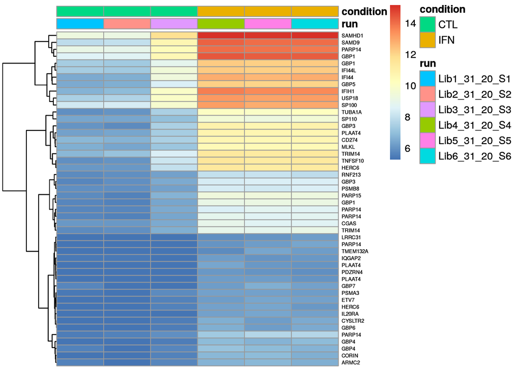

```r
# selection des gène significativement sur-réguler
select <- na.omit(resUsName$Row.names[resUsName$padj<0.05 & resUsName$log2FoldChange>4])
#select <-select[1:10] #pas utile

#définition des nom
row.names(samples)=samples$run
resUsNameVsd <- merge(as.data.frame(resUsName),assay(vsd),by.x="Row.names",by.y=0)
row.names(resUsNameVsd) <- resUsNameVsd$Row.names

#création de la pheatmap
h=pheatmap(resUsNameVsd[select,10:15], cluster_rows=TRUE, show_rownames=TRUE,show_colnames=FALSE,
           cluster_cols=FALSE, annotation_col=samples, labels_row=resUsNameVsd[select,"external_gene_name"],fontsize_row=5)
h
```

```r
ggsave(h,file="heatmapUpReg.png")
```

Nous pouvons ici il constaté, en premier lieu, que (principalement dans la partie du haut) on a bel et bien une différence au niveau de l’expression des gènes entre l’induction d’IFN et le contrôle. Par ailleurs, comme on a pu le voir précédemment, le contrôle numéro trois possède bien une différence d’expression qui est différent des deux autres contrôles bien que celui-ci reste moins fort que pour le cas de l’induction d’IFN pour les trois échantillons.

Puis, nous avons réaliser la pheatmap pour les gènes sous-réguler avec un log2FoldChange < -1:

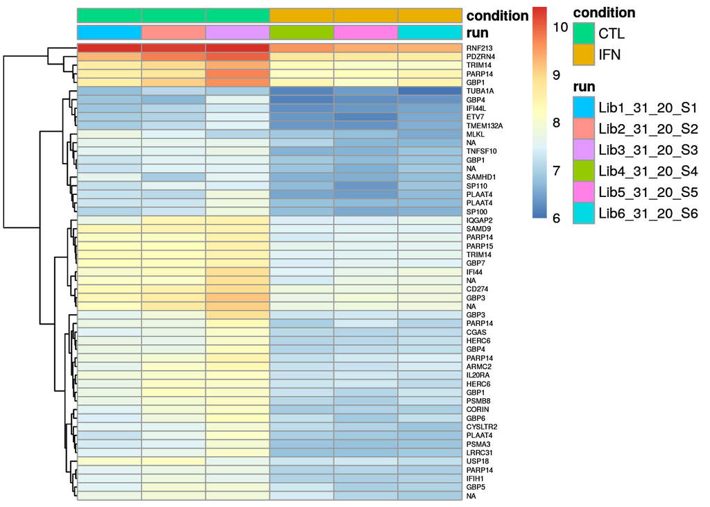

```r
# selection des gène significativement sous-réguler
select2 <- na.omit(resUsName$Row.names[resUsName$padj<0.05 & resUsName$log2FoldChange<(-1)])
#select2 <-select[1:10] #pas utile

#définition des nom
row.names(samples)=samples$run
resUsNameVsd <- merge(as.data.frame(resUsName),assay(vsd),by.x="Row.names",by.y=0)
row.names(resUsNameVsd) <- resUsNameVsd$Row.names

#création de la pheatmap
h=pheatmap(resUsNameVsd[select2,10:15], cluster_rows=TRUE, show_rownames=TRUE,show_colnames=FALSE,
           cluster_cols=FALSE, annotation_col=samples, labels_row=resUsNameVsd[select,"external_gene_name"],fontsize_row=5)
h
```

```r
ggsave(h,file="heatmapDownReg.png")
```

En premier lieu, je tiens a préciser que l’on a fait l’analyse pour log2FoldChange < -1 car pour un log2FoldChange plus bas, il n’y a de possibilité de faire le graphique pour manque de données. Cela peut ainsi expliquer pourquoi il n’y a pas une très grande différence pour les gènes sous réguler au niveau de la transcription de ces derniers. Cette analyse nous confiant dans le faite Que l’induction interféron a un impact positif principalement sur l’expression de certains gènes et non de la négative régulation.

## Comparaison du groupe ech6 contre des donnée similaire de d’autres personnes:

Ici, on normalise les données récupérées de l’autre groupe afin de pouvoir par la suite le comparer avec notre résultat :

```r
# téléchargement des données
resBatHolzer<-read.csv("https://www.rna.uni-jena.de/supplements/mda/data/deseq2/RNA/Mock_6h_RNA_vs_IFN_6h_RNA/deseq2_Mock_6h_RNA_IFN_6h_RNA_full.csv")

# Normalisation du nom
colnames(resBatHolzer)[2] <- c("external_gene_name") #change column name to be the same as ours

# conjugaison avec notre résultat à fin de comparer
CommonGenesUsHolze <- merge(resUsName,resBatHolzer,by="external_gene_name") #11364 genes in common
```

Réalisation du Pearson’s Chi-squared test entre notre et leurs résultats :

```r
# détermination de si notre résultat est sous- ou sur- réguler ou bien non réguler
CommonGenesUsHolze$ourTest="nonreg"
CommonGenesUsHolze$ourTest[CommonGenesUsHolze$padj.x<0.05&CommonGenesUsHolze$log2FoldChange.x>0]="Up"
CommonGenesUsHolze$ourTest[CommonGenesUsHolze$padj.x<0.05&CommonGenesUsHolze$log2FoldChange.x<0]="Down"

# détermination de si leur résultat est sous- ou sur- réguler ou bien non réguler
CommonGenesUsHolze$theirTest="nonreg"
CommonGenesUsHolze$theirTest[CommonGenesUsHolze$padj.y<0.05&CommonGenesUsHolze$log2FoldChange.y>0]="Up"
CommonGenesUsHolze$theirTest[CommonGenesUsHolze$padj.y<0.05&CommonGenesUsHolze$log2FoldChange.y<0]="Down"
chisq.test(table(us=CommonGenesUsHolze$ourTest,them=CommonGenesUsHolze$theirTest))
```

```
##
##  Pearson's Chi-squared test
##
## data:  table(us = CommonGenesUsHolze$ourTest, them = CommonGenesUsHolze$theirTest)
## X-squared = 1717.2, df = 4, p-value < 2.2e-16
```

Nous pouvons ainsi y voir tu la p-value est très faible. De se fête, cela signifie qu’il y a très peu de chances que si il y a une différence que cela soit du au hasard.